# Data Wrangling with R

Author

Abigail Sewell

Published

March 4, 2026

**Note**

**Note** This codebook will follow the structure and content of the published codebook for this project: https://jmjung.quarto.pub/m05-1-principles-data-wrangling-with-tidyverse-in-r/

# Overview

## Learning Outcomes

> By the end of this module, you will be able to:
- Describe the concept of Data Wrangling.
- Describe how Tibbles are different from data frames
- Explain how to convert wide or long data to “Tidy” data
- Explain how to merge relational data sets using join functions. (Next module)
- Explain how to use grouped mutates and filter together.
- Be familiar with major dplyr functions for transforming data.
- Create a new variable with mutate() and case_when().
- Use the pipe operator to shape the data to prepare for analysis and visualization

## The testbook chapters cover

- ch3: Data transformation
- ch5: Data Tidying
- ch13: Numbers

# Intro to Data Wrangling

## Loading the packages

- to add a codechunk, use shortcut cmd+alt+i

```r
#options(repos = c(CRAN = "https://cloud.r-project.org"))
#install.packages(tidyverse)
#library(tidyverse)
```

# What is tidyverse

The tidyverse is a collection of r packges that share common design philosophy and are designed to work together seamlessly. the tidyverse includes packages for data manipulation, visualization, and modeling, among other tasks. some core packages are: - ggplot2 - dplr - tidyr - readr - purrr - tibble - stringr - forcats

## Initial Data Preparation and Exploration

```r
options(repos = c(CRAN = "https://cloud.r-project.org"))

install.packages("dplyr")
library(dplyr)
install.packages("nycflights13")
library(nycflights13)
```

# data wrangling with dplyr

Note: use shift, alt, i, for multi-cursor activision

airlines Airline names. airports Airport metadata flights Flights data planes Plane metadata. weather Hourly weather data

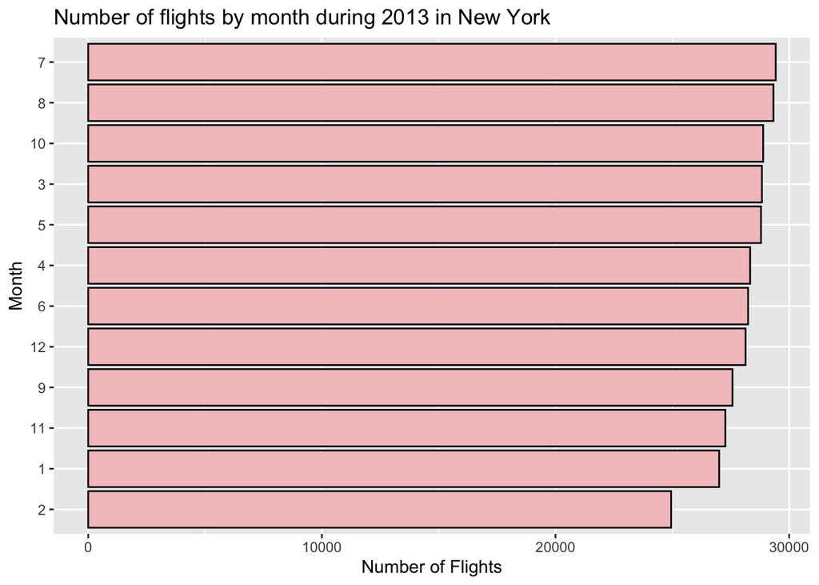

```r
library(tidyverse)
library(nycflights13)

flights |>
  count(month) |>
  mutate(month = as_factor(month),
         month = fct_reorder(month, n)) |>
  ggplot(aes(month, n)) +
  geom_col(fill = "#F3C4C7", color = "black") +
  coord_flip()+
  labs(x = "Month",
       y = "Number of Flights",
       title = "Number of flights by month during 2013 in New York")
```